# L03 ggplot 2

Data Visualization (STAT 302)

Author

Lauren Kennedy

## Overview

The goal of this lab is to continue the process of unlocking the power of `ggplot2` through constructing and experimenting with a few basic plots.

## Datasets

We will be using the BRFSS survey which was introduced in the last lab. The data was supplied in `cdc.txt` file and should be in your `/data` subdirectory. If not, you need to download the last lab to get this data file. As a reminder, the dataset contains 20,000 complete observations/records of 9 variables/fields, described below.

- `genhlth` - How would you rate your general health? (excellent, very good, good, fair, poor)
- `exerany` - Have you exercised in the past month? (`1 = yes`, `0 = no`)
- `hlthplan` - Do you have some form of health coverage? (`1 = yes`, `0 = no`)
- `smoke100` - Have you smoked at least 100 cigarettes in your life time? (`1 = yes`, `0 = no`)
- `height` - height in inches
- `weight` - weight in pounds
- `wtdesire` - weight desired in pounds
- `age` - in years
- `gender` - `m` for males and `f` for females

```r
# Load package(s)
library(tidyverse)
library(hexbin)


# Load data
cdc <- read_delim(file = "data/cdc.txt", delim = "|") %>%
  mutate(genhlth = factor(genhlth,
                          levels = c("excellent",
                                     "very good",
                                     "good",
                                     "fair",
                                     "poor")))
```

## Exercise 1

Using the `cdc` dataset, we want to look at the relationship between height and weight. Recreate the following graphics as precisely as possible.

### Plot 1

*Hints:*

- Transparency is 0.2
- Minimal theme

**Solution**

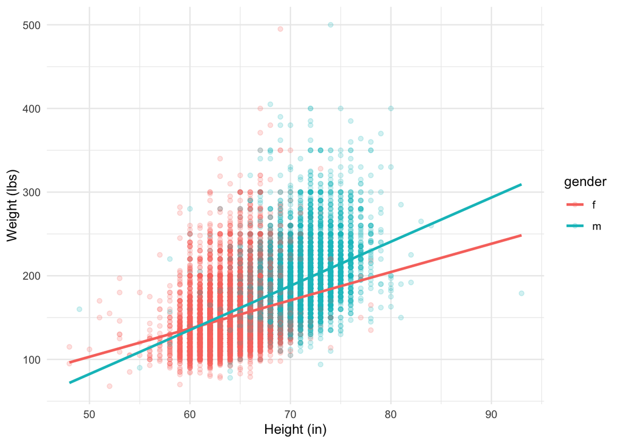

```r
plot_base <-ggplot(cdc,aes(height,weight))+
  ylab("Weight (lbs)")+
  xlab("Height (in)")+
  theme_minimal()

ggplot(cdc,aes(height,weight))+
  geom_point(aes(color = gender),alpha=0.2)+
  geom_smooth(aes(color = gender), method = "lm", se=F, fullrange = TRUE)+
  theme_minimal() +
  ylab("Weight (lbs)")+
  xlab("Height (in)")
```

### Plot 2

*Hints:*

- linewidth = 0.7

**Solution**

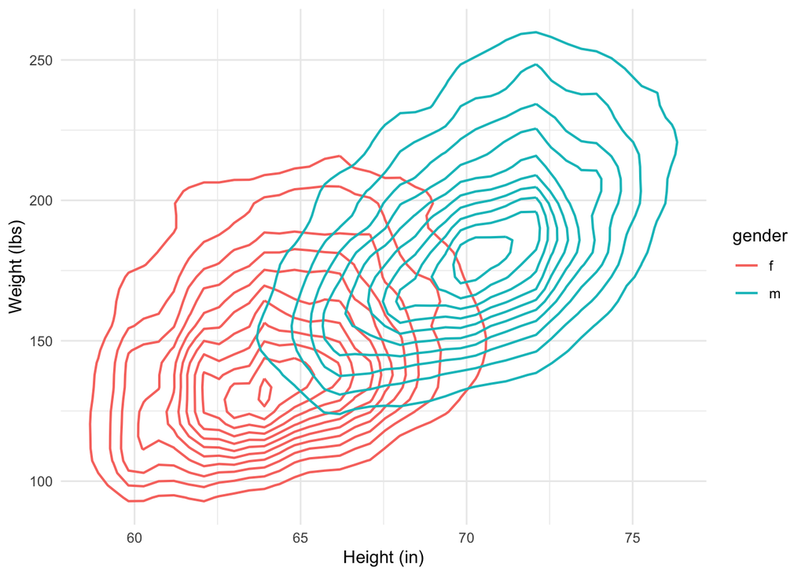

```r
plot_base+
  geom_density_2d(aes(color=gender),lwd=0.7)
```

### Plot 3

*Hints:*

- `bins` set to 35

**Solution**

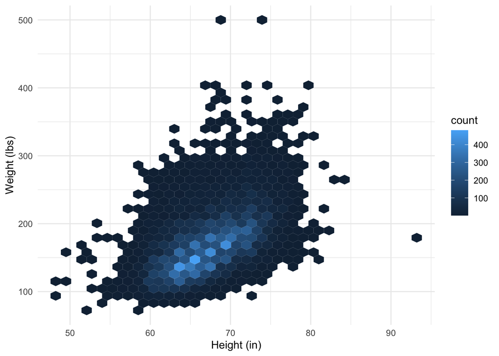

```r
plot_base+
  stat_binhex(bins = 35)
```

### Plot 4

*Hints:*

- use a stat layer, not a geom layer
- `geom = "polygon"`

**Solution**

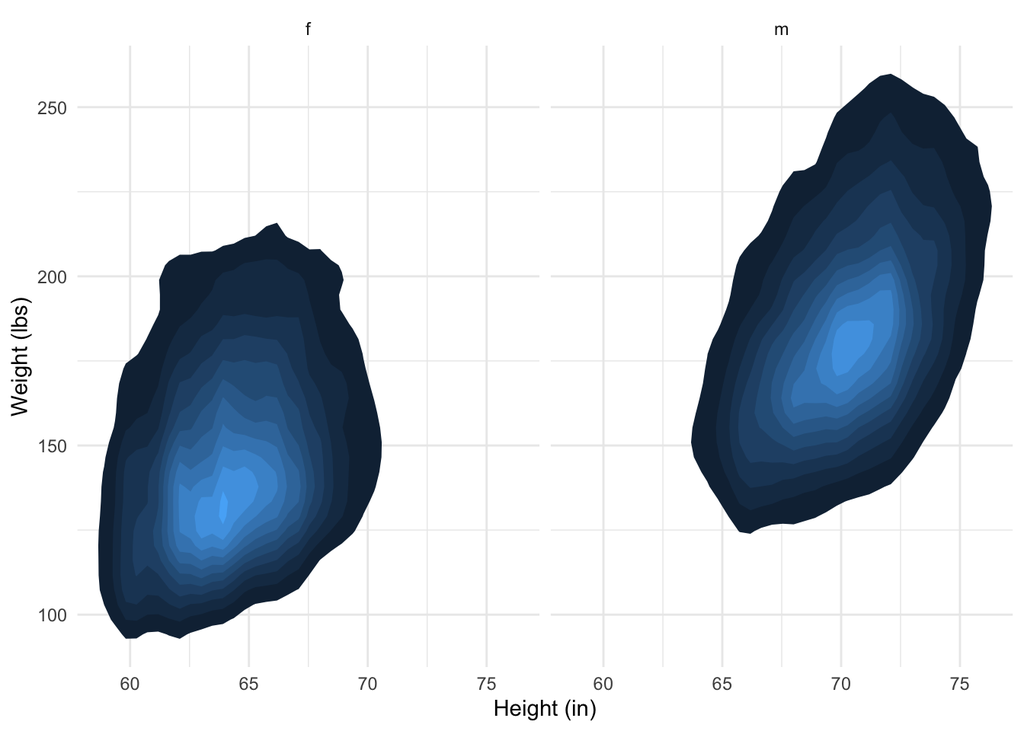

```r
plot_base +
  stat_density_2d(
    geom = "polygon",
    aes(fill = after_stat(level)),
    show.legend = FALSE) +
  facet_wrap(~gender)
```

## Exercise 2

Using the `cdc_means` dataset derived from the `cdc` dataset, recreate the following graphic as precisely as possible.

*Hints:*

- Hex color code `#56B4E9`
- 95% confidence intervals (1.96 or `qnorm(0.975)`)
- Some useful values: 0.1, 0.7
- geom_errorbar function

```r
# data wrangling
# calc mean and se for CI
cdc_means <- cdc |>
  mutate(wtloss = weight - wtdesire) |>
  group_by(genhlth) |>
  summarize(
    mean = mean(wtloss),
    se = sd(wtloss) / sqrt(n())
  ) |>
  mutate(genhlth = fct_reorder(factor(genhlth), desc(mean)))
```

**Solution**

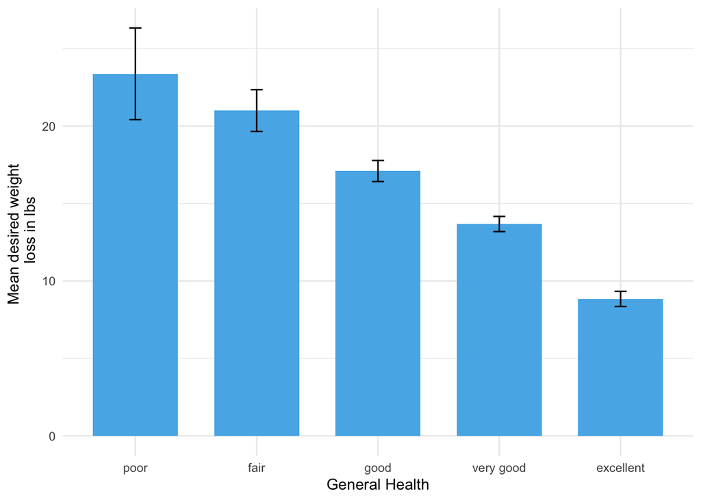

```r
ggplot(cdc_means,aes(x=genhlth, y=mean,
                     ymin = mean - qnorm(0.975)*se,
                     ymax = mean + qnorm(0.975)*se))+
  geom_col(fill = "#56B4E9", width = 0.7)+
  geom_errorbar(width = 0.1) +
  theme_minimal() +
  ylab("Mean desired weight \n loss in lbs")+
  xlab("General Health")
```

## Exercise 3

Using the `cdc_weight_95ci` dataset derived from the `cdc` dataset, recreate the following graphic as precisely as possible.

*Hints:*

- Useful values: 0.1, 0.5
- Need to know CI formula
- use position_dodge to jitter points
- try geom_errorbarh

```r
# data wrangling
# calculate mean, se, and margin of error for CI formula
cdc_weight_95ci <- cdc |>
  group_by(genhlth, gender) |>
  summarise(
    mean_wt = mean(weight),
    se = sd(weight) / sqrt(n()),
    moe = qt(0.975, n() - 1) * se
  ) |>
  ungroup()
```

**Solution**

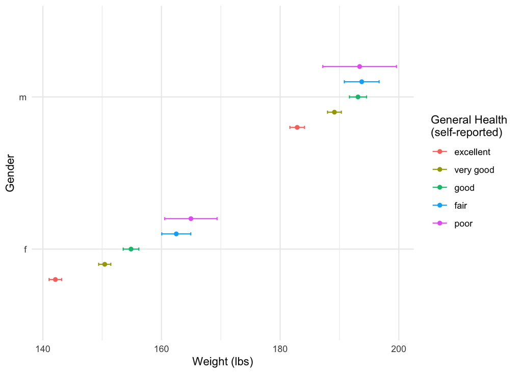

```r
ggplot(cdc_weight_95ci,aes(x=mean_wt, y=gender,
                     color=genhlth))+
  geom_point(position = position_dodge(width = 0.5))+
  geom_errorbarh(aes(
    xmin = mean_wt - moe,
    xmax = mean_wt + moe),
    position = position_dodge(width = 0.5),
    height = 0.1) +
  theme_minimal() +
  labs(
    x = "Weight (lbs)",
    y = "Gender",
    color = "General Health \n(self-reported)")
```